# LAB 03

Nana Ama Obeng Nti

```r
library("MASS")
cars <- Cars93
```

## QUESTION 1

The Cars93 dataset in the MASS package contains data from 93 cars on sale in the USA in 1993. Randomly select 40 cars as the training dataset and the remaining 53 cars as the test dataset. Save both datasets as csv files. Find out the number of USA and non-USA cars in the training dataset.

### Question 1a.

Randomly select 40 cars as training dataset and the remaining 53 as test dataset.

```r
set.seed(10)
n <- nrow(cars)
nrows <- 1:n
trn <- sort(sample(1:n,40))
trn
```

```
 [1]  4  6  8 10 11 16 20 21 23 24 25 28 29 30 34 37 38 39 44 45 47 48 49 51 53 54 55 56 57
[30] 60 62 63 64 70 78 79 82 87 92 93
```

```r
tes <- nrows[-trn]
tes
```

```
 [1]  1  2  3  5  7  9 12 13 14 15 17 18 19 22 26 27 31 32 33 35 36 40 41 42 43 46 50 52 58
[30] 59 61 65 66 67 68 69 71 72 73 74 75 76 77 80 81 83 84 85 86 88 89 90 91
```

```r
training.dataset <- cars[trn,]
test.dataset <- cars[tes,]
```

### Question 1b

Save both datasets as csv files

```r
write.csv(training.dataset, file = "training.dataset.csv", row.names = FALSE)
write.csv(test.dataset, file = "test.dataset.csv", row.names = FALSE)
```

### Question 1c

Number of USA and non-USA cars in the training dataset

```r
table(training.dataset$Origin)
```

```
    USA non-USA
     20      20
```

## QUESTION 2

Assume that the probabilities of boy and girl births are 0.515 and 0.485, respectively. Use the *sample()* function to simulate 10 births and print out the result. How many boys and girls do you get out of 10 births? Then simulate 10,000 births. How many boys and girls do you get out of 10,000 births?

### Question 2a

10 births and the number of boys and girls in the 10 births

```r
births.1 <- sample(c("boy","girl"),size = 10,replace = TRUE,prob = c(0.515,0.485))
births.1
```

```
 [1] "boy"  "boy"  "boy"  "girl" "boy"  "boy"  "boy"  "boy"  "boy"  "girl"
```

```r
table(births.1)
```

```
births.1
 boy girl
   8    2
```

### Question 2b

10,000 births and the number of boys and girls in that birth

```r
births.2 <- sample(c("boy","girl"),size = 10000,replace = TRUE,prob = c(0.515,0.485))
births.2
```

[output not shown]

[output cut: 70 more lines]

```r
table(births.2)
```

```
births.2
 boy girl
5177 4823
```

## QUESTION 3

Assume that the probabilities of boy and girl births are 0.515 and 0.485, respectively. What’s the probability of having exactly 3 boys out of 10 births? What’s the probability of having 8 or more boys out of 10 births? Plot both the density function and cumulative probability function of the number of boy births out of 10.

### Question 3a

Exactly 3 boys out of 10 births P(X = 3)

```r
ext.3 <- dbinom(3,10,0.515)
ext.3
```

```
[1] 0.1034654
```

### Question 3b

8 or more boys out of 10 births P(X >= 8)

```r
more.8 <- pbinom(7,10,0.515,lower.tail = F)
more.8
```

```
[1] 0.06605068
```

### Question 3c

Plot both the density function and cummulative function respectively

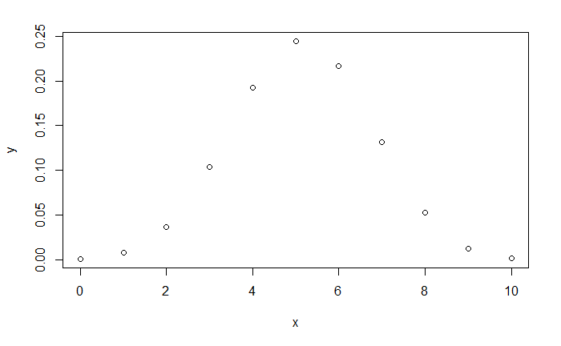

```r
n <- 10
x <- 0:n
y <- dbinom(x,n,0.515)
plot(x,y)
```

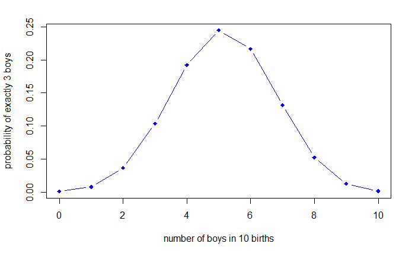

```r
plot(x,y,type="b",pch=18,col="blue", xlab="number of boys in 10 births",ylab="probability of exactly 3 boys")
```

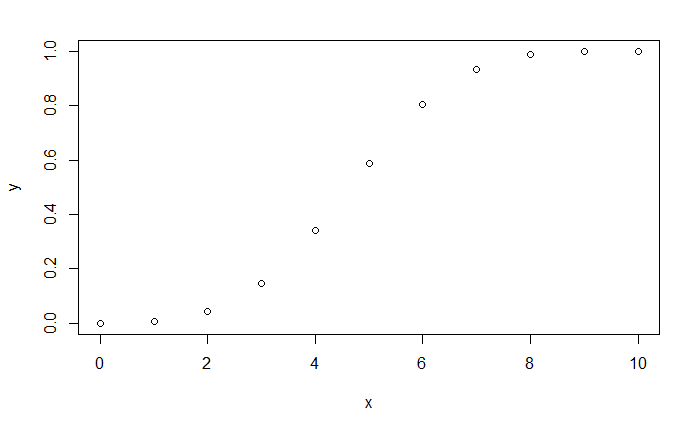

```r
y <- pbinom(x,n,0.515)
plot(x,y)
```

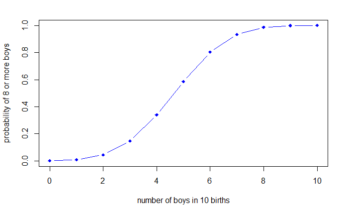

```r
plot(x,y,type="b",pch=18,col="blue",xlab="number of boys in 10 births",ylab="probability of 8 or more boys")
```

## QUESTION 4

If cars arrive randomly at a traffic light at the rate of five every ten seconds. What the probability that exactly four cars arrive in the next ten seconds? What’s the probability that more than five cars arrive in the next ten seconds? Plot the density function of 0-20 cars arriving in the next ten seconds.

### Question 4a

Probability that exactly 4 cars arrive in the next 10secs.

```r
ext.4 <- dpois(4,lambda = 5)
ext.4
```

```
[1] 0.1754674
```

### Question 4b

Probability that more that 5 cars arrive in the next 10secs

```r
more.5 <- 1 - ppois(5,lambda = 5)
more.5
```

```
[1] 0.3840393
```

### Question 4c

Plot the density function of 0-20 cars arriving in the next 10secs.

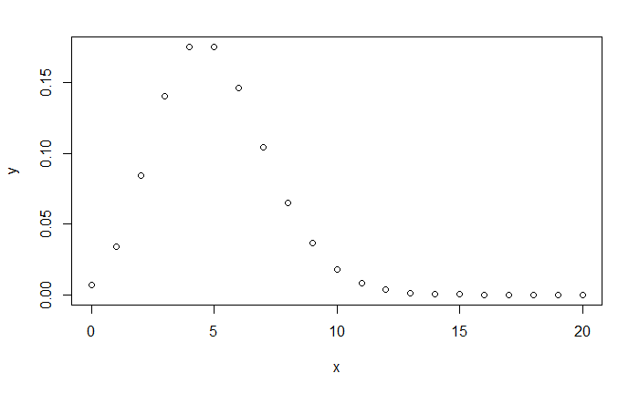

```r
n <- 20
x <- 0:n
y <- dpois(x,lambda = 5)
plot(x,y)
```

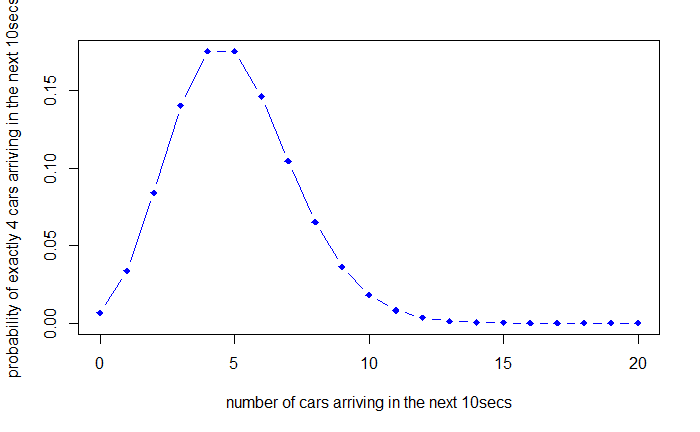

```r
plot(x,y,type = "b",pch = 18,col="blue",xlab="number of cars arriving in the next 10secs",ylab="probability of exactly 4 cars arriving in the next 10secs")
```